# DWEI5_Aula08_JS-TiposDeDados

### 11. Escape Sequence

| Escape Sequence | Significado | Exemplo | Saída |
| --- | --- | --- | --- |
| \\ | Exibe uma barra invertida. | console.log("Ana \ Paula") |  |
| \' | Exibe uma aspas simples. | console.log("Ana \' Paula") |  |
| \" | Exibe uma aspas duplas. | console.log("Ana \" Paula") |  |
| \n | Insere uma quebra de linha. | console.log("Ana \n Paula") |  |
| \u | Insere um caracter unicode. Deve ser acompanhado com 4 números. | console.log("Isto é um sol: \u2600 .") |  |
| \t | Insere uma tabulação. | console.log("Ana \t Paula") |  |

### 12. Entrada de Dados

- Uma das formas de entrar com os dados, é via **prompt do navegador**. Outra, **via formulário**.
  - **prompt()**: Exibe uma informação solicitando a ação do usuário com um espaço para digitar e dois botões ok, cancelar (ou Esc).
- Exibir mensagens no navegador, ou perguntar e aguardar uma ação:
  - **alert()**: Exibe a informação indicada entre parênteses com um botão de ok.
  - **confirm()**: Exibe a informação indicada entre parênteses com dois botões: ok, cancelar (ou Esc). Se escolher ok, o retorno é true, caso contrário é, false.

```
/* no console digite */
alert("Seja bem vindo!');

confirm("Você gosta de estudar?");

prompt("Indique sua idade: ");
```

**Saída:**  
**Alert()**:

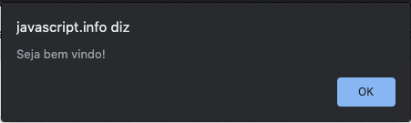

**Confirm()**:

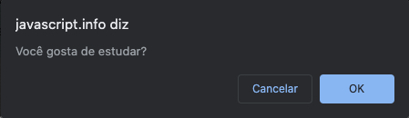

**Prompt()**:

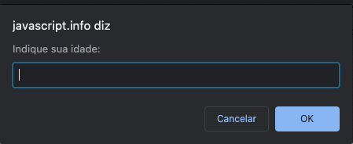

### 13. Atribuição

- A atribuição é feita por meio do uso do símbolo =.
- Em javascript é possível efetuar a tribuição encadeada, por exemplo, de acordo com [Javascript.info]:
  - As atribuições encadeadas são avaliadas da direita para a esquerda.
  - Em primeiro lugar, a expressão mais à direita 2 + 2 é avaliado e então atribuído às variáveis da esquerda: c, b e a.
  - No final, todas as variáveis compartilham um único valor.

```
let a, b, c;

a = b = c = 2 + 2;
```

### 14. Operadores Aritméticos

Símbolo

Significado

Descrição

Exemplo

Saída

++

incremento

Adiciona um ao operando.  
Se usado como operador **prefixado (++x)**, retorna o valor de seu operando **após a adição**.  
Se usado como operador **pósfixado (x++)**, retorna o valor de seu operando **antes da adição**.

Se x é 3, então ++x, tanto ++x e x serão 4.  
E x++, x++ será 3, e x será 4.

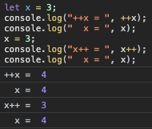

--

decremento

Subtrai um de seu operando. O valor de retorno é análogo àquele do operador de incremento.

Se x é 3, então --x, tanto --x e x serão 2.  
E x--, x-- será 3, e x será 2.

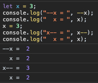

-

subtração

Retorna a negação de seu operando, ou o resultado do valor subtraído.

Se x é 3, então -x é -3.  
E retorna x, 3.

+

adição

Tenta converter o operando em um número, sempre que possível.

Se +x = "3", retorna 3.  
Se +x = true, retorna 1.

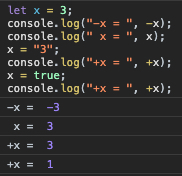

%

divisão (resto ou módulo)

Retorna o inteiro restante da divsão dos dois operandos.

Se x = 12, y = 5, então retorno será 2.

exponenciação

Calcula a base elevada à potência do expoente.

Se x = 2, y = 3, então x elevado a y, retorna 8.  
Se x = 10, y = -1, então retorna 0.1.  
Se x = 9, y = 1/2, então retorna a raiz de x.

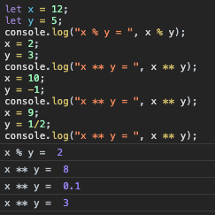

### 15. Operadores Relacionais

- Um operador relacional compara seus operandos e sempre **retorna um valor booleano** baseado em se a comparação é verdadeira:
  - Caso seja verdadeira, True ou 1.
  - Caso seja falso, False ou 0.

| Símbolo | Significado | Exemplo Considerando: a = 10 e b = 15. | Saída |
| --- | --- | --- | --- |
| < | menor. | a < b | true |
| <= | menor ou igual a. | a <= b | true |
| > | maior. | a > b | false |
| >= | maior ou igual a. | a >= b | false |
| == | igual. | a == b | false |
| != | não igual (diferente). | a != b | true |
| !== | estritamente não igual. Retorna verdadeiro caso os operandos não sejam iguais e/ou não sejam do mesmo tipo. | a !== b | true |
| === | estritamente igual. Retorna verdadeiro caso os operandos sejam iguais e do mesmo tipo. | a === b | false |

**Saída:**

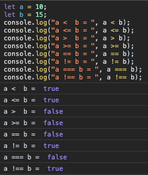

### 16. Operadores Lógicos

- O valor **lógico** é um tipo de **dado binário**: verdadeiro (True), ou falso (False).

| and && | True | False |
| --- | --- | --- |
| True | True | False |
| False | False | False |

| or | True | False |
| --- | --- | --- |
| True | True | True |
| False | True | False |

- O **or** é representado por **dois pipe** seguidos.

| not ! |  |
| --- | --- |
| ! True | False |
| ! False | True |

#### Exemplo

```
let nome = 'Ana Paula';
let maiorIdade = true;
let habilitada = false;
let dirigirOk = maiorIdade && habilitada;
let naoPode = !dirigirOk;

console.log('Dirigir: ', dirigirOk);
console.log('Não dirigir: ', naoPode);
```

### 16.1. Comparações não booleanas

- Comparações lógicas com valores não booleanos. Para saber mais [MDN Web Docs - Truthy](https://developer.mozilla.org/en-US/docs/Glossary/Truthy) ou [MDN Web Docs - Falsy](https://developer.mozilla.org/en-US/docs/Glossary/Truthy).
- No Javascript temos o conceito de Truthy e Falsy.
- Nem sempre as comparações lógicas retornarão um booleano.
- **O que é um valor Falsy**: Um valor falsy é um valor que se traduz em falso quando avaliado em um contexto Boolean.
- Valores Falsy:
  - false
  - null
  - undefined
  - 0
  - NaN
  - ' '

```
// Contexto booleano
false || true        // Saída: true
false || 'Ana'       // Saída: 'Ana'
false || 1.          // Saída: 1

// Os operadores lógicos or, efetuam a primeira comparação e se já encontrarem um valor truthy, eles ignoram as seguintes.
false || 1 || 3      // Saída: 1
```

- **Trurhy**: Se não for identificado como falsy, ele será truthy.

### 17. Operadores de Atribuição

### Compostos

[output not shown]

**Saída:**

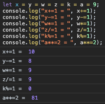

### 18. Outros

- **Exponenciação ou potência**:
  - Potenciação é a operação matemática que eleva um número a uma determinada potência.
- **Radiciação**:
  - A radiciação é o inverso da potenciação.
  - Podemos obter a radiciação utilizando as propriedades matemáticas.
- **Todo número elevado ao seu inverso é a sua raiz**, logo:
  - N elevado a (1/2), obtemos a raiz quadrada de N. Elevado a (1/3), raiz cúbica.
- **Observação**:
  - Para saber mais sobre outros operadores, consulte [Javascript.info](https://javascript.info/nullish-coalescing-operator).
  - Exibindo conteúdo no seu HTML a partir do javascript:
    - Utilizando o método **.innerHTML**.
    - Utilizando o método **.textContent**.

```
<!DOCTYPE html>
<html lang="pt-br">
<head>
  <meta charset="UTF-8">
  <title>Exemplo Javascript</title>
</head>
<body>
<h1> Informações Pessoais </h1>
<div id="id1">
  <p>Meu nome é</p>
  <p>Utilizando textContent: <span id="texto1"></span></p>
  <p>Utilizando innerHTML: <span id="texto2"></span></p>
</div>
<script>
  let c = document.getElementById("texto1");
  let d = document.getElementById("texto2");
  let a = prompt("Nome: ");
  c.textContent = a;
  d.innerHTML = a;
</script>
</body>
</html>
```

**Saída:**

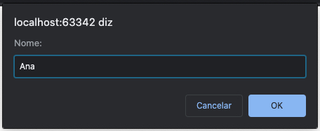

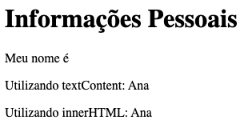

### Exemplos:

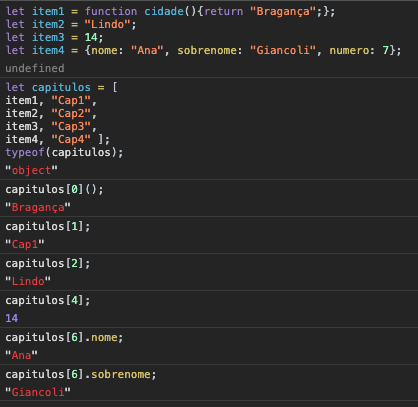

### 19. Inserindo um script no index.html

- A inserção do Javascript em uma página web pode ser feita de duas maneiras:
  - Uma diretamente no código de extensão .html, seja dentro da tag **< head >** ou da tag **< body >**.
  - Criando um **arquivo de extensão .js** e acionando a partir do html.
- **Sintaxe**:

**Script incorporado no html**.

```
<!-- Script inserido no head ou no body -->
<script>
    .... inserir seu código JS aqui ...
</script>
```

**Script externo ao html**.

```
<!-- src deve ser preenchido com o caminho do script -->
<script src="..."></script>
```

### 19.1. Atributos dos scripts

### 19.1.1. Defer

- O atributo **defer** indica ao navegador que poderá continuar trabalhando com a página, carregando o script "em segundo plano" e, em seguida, executar o script quando concluir o carregamento.
- **Sintaxe**:

```
<script defer src="..."></script>
```

- **Observações**:
  - Os scripts **defer** nunca bloqueiam a página.
  - Sempre são executados quando o DOM está pronto, mas antes do evento para carregamento dos conteúdos do DOM (DOMContentLoaded).
  - Este atributo funciona somente com scripts externos.

### 19.1.2. Async

- O atributo **async** indica que um script é completamente independente:
- O conteúdo das páginas são processados e exibidos, independente da execução do script.
- O evento de carregamento dos conteúdos do DOM (DOMContentLoaded) e scripts assíncronos são independentes um do outro:
  - o DOMContentLoaded pode ocorrer antes de um script assíncrono (se um script assíncrono terminar de carregar após a conclusão da página).
  - ou após um script assíncrono (se um script assíncrono for curto ou estiver no cache HTTP).
- **Observações**:
  - Existindo diversos scripts **async**, os mesmos serão executados em qualquer ordem, o que dependerá de seu tamanho.
  - Os scripts **async** não bloqueiam os conteúdos da página, logo o DOM é carregado, independente da execução antes ou depois do evento DOMContentLoaded.
  - São totalmente independentes.

### 19.2. Selecionando itens do DOM

- Consulte [Javascript.info](https://javascript.info/searching-elements-dom).

### 19.3. Criando uma estrutura básica

```
<!DOCTYPE html>
<html lang="pt-br">
<head>
    <meta charset="UTF-8">
    <title>Básico JS</title>
    <!-- Utilizando o script incorporado no head -->
    <script>
        <!-- escreva seu código aqui -->
    </script>
</head>
<body>
    <!-- Utilizando o script incorporado no body -->
    <script>
        <!-- escreva seu código aqui -->
    </script>

    <!-- Utilizando o script externo -->
    <script src="..."></script>
</body>
</html>
```

#### Exemplo:

```
<!DOCTYPE html>
<html lang="pt-br">
<head>
    <meta charset="UTF-8">
    <title>Básico JS</title>
</head>
<body>


<!-- Utilizando o script incorporado no body -->
<script>
    let vendas = "Toyota" ;
    function tipoCarro(nome) {
        if (nome == "Fiat") {
            return nome;
        } else {
            return "Desculpa, não vendemos carros " + nome + ".";
        }
    }
    let carro = {
        meuCarro : "Punto",
        getCarro : tipoCarro ("Fiat"),
        especial : vendas
    };
    console.log(carro.meuCarro); // Punto
    console.log(carro.getCarro); // Fiat
    console.log(carro.especial); // Toyota

    console.log(tipoCarro("Ford"));
</script>
</body>
</html>
```

### Referências

- Esta aula foi elaborada a partir do conteúdo disponibilizado em cada um dos links indicados no próprio texto.
- [Basques, Kayce - Console API Reference](https://developers.google.com/web/tools/chrome-devtools/console/api?utm_source=dcc&utm_medium=redirect&utm_campaign=2016q3).
- [Javascript.info](https://javascript.info/variables).

### Perguntas

- Esclareça suas eventuais dúvidas durante as aulas.
- Ou pelo *E-mail*: paulagiancoli@ifsp.edu.br.
- Ou pelo *Fórum* do componente curricular.

*ADS - HTML5, CSS3, JS - 5o. módulo*.  
Modelo e formato elaborado por profa. Ana Paula Müller Giancoli - BSD 2-Clause License. - Julho.2020.